# Titanic EDA

Omar Hesham

# $Agenda$

1.Introduction

*1.1 Loading Data

*1.2 Summariznig it

2.Removing NAs

3.New Features?

*3.1 Nobles ?

*3.2 Travelling Alone ?

4. Making Prediction Using Decision Tree

## $Introduction$

Welcome To My First EDA Where I Will Do Some Basic Minuplation And Prediction With Titanic DataSet But First Let’s Load Some Packages Which Might Help us to do so

```r
library(rpart) #Decision Tree
library(dplyr) #Data Frame Minuplation
library(ggplot2) #Plotting
library(data.table)
library(rattle)
library(rpart.plot)
library(RColorBrewer)
```

### Loading Data

We Have 2 DataSets,Train DataSet Which has the Correct Predictions And The Test Which We Should Apply our model on it So Let’s Load Them And See The Variables

```r
train<-read.csv("train.csv",stringsAsFactors = F)
test<-read.csv("test.csv",stringsAsFactors = F)
```

### Summarizing it

Before Making any Work On the data We Must Make Sure it’s Clean And Well-Organized So Let’s Look At The Both DataSets

```r
summary(train)
```

```
##   PassengerId       Survived          Pclass          Name
##  Min.   :  1.0   Min.   :0.0000   Min.   :1.000   Length:891
##  1st Qu.:223.5   1st Qu.:0.0000   1st Qu.:2.000   Class :character
##  Median :446.0   Median :0.0000   Median :3.000   Mode  :character
##  Mean   :446.0   Mean   :0.3838   Mean   :2.309
##  3rd Qu.:668.5   3rd Qu.:1.0000   3rd Qu.:3.000
##  Max.   :891.0   Max.   :1.0000   Max.   :3.000
##
##      Sex                 Age            SibSp           Parch
##  Length:891         Min.   : 0.42   Min.   :0.000   Min.   :0.0000
##  Class :character   1st Qu.:20.12   1st Qu.:0.000   1st Qu.:0.0000
##  Mode  :character   Median :28.00   Median :0.000   Median :0.0000
##                     Mean   :29.70   Mean   :0.523   Mean   :0.3816
##                     3rd Qu.:38.00   3rd Qu.:1.000   3rd Qu.:0.0000
##                     Max.   :80.00   Max.   :8.000   Max.   :6.0000
##                     NA's   :177
##     Ticket               Fare           Cabin             Embarked
##  Length:891         Min.   :  0.00   Length:891         Length:891
##  Class :character   1st Qu.:  7.91   Class :character   Class :character
##  Mode  :character   Median : 14.45   Mode  :character   Mode  :character
##                     Mean   : 32.20
##                     3rd Qu.: 31.00
##                     Max.   :512.33
##
```

```r
summary(test)
```

```
##   PassengerId         Pclass          Name               Sex
##  Min.   : 892.0   Min.   :1.000   Length:418         Length:418
##  1st Qu.: 996.2   1st Qu.:1.000   Class :character   Class :character
##  Median :1100.5   Median :3.000   Mode  :character   Mode  :character
##  Mean   :1100.5   Mean   :2.266
##  3rd Qu.:1204.8   3rd Qu.:3.000
##  Max.   :1309.0   Max.   :3.000
##
##       Age            SibSp            Parch           Ticket
##  Min.   : 0.17   Min.   :0.0000   Min.   :0.0000   Length:418
##  1st Qu.:21.00   1st Qu.:0.0000   1st Qu.:0.0000   Class :character
##  Median :27.00   Median :0.0000   Median :0.0000   Mode  :character
##  Mean   :30.27   Mean   :0.4474   Mean   :0.3923
##  3rd Qu.:39.00   3rd Qu.:1.0000   3rd Qu.:0.0000
##  Max.   :76.00   Max.   :8.0000   Max.   :9.0000
##  NA's   :86
##       Fare            Cabin             Embarked
##  Min.   :  0.000   Length:418         Length:418
##  1st Qu.:  7.896   Class :character   Class :character
##  Median : 14.454   Mode  :character   Mode  :character
##  Mean   : 35.627
##  3rd Qu.: 31.500
##  Max.   :512.329
##  NA's   :1
```

```r
nrow(train)==nrow(test)
```

```
## [1] FALSE
```

The Missing Column is the “Survived” in the test data So We Put it And Assign it to NA Temporary , Add A Feature That Help Us to Seperate The 2 DataSets After We Finish Cleaning And rbind them after that.

```r
test$Survived<-NA
train$IsTrain<-TRUE
test$IsTrain<-FALSE
full<-rbind(train,test)
```

So Let’s Look at The Full DataSet

```r
str(full)
```

```
## 'data.frame':    1309 obs. of  13 variables:
##  $ PassengerId: int  1 2 3 4 5 6 7 8 9 10 ...
##  $ Survived   : int  0 1 1 1 0 0 0 0 1 1 ...
##  $ Pclass     : int  3 1 3 1 3 3 1 3 3 2 ...
##  $ Name       : chr  "Braund, Mr. Owen Harris" "Cumings, Mrs. John Bradley (Florence Briggs Thayer)" "Heikkinen, Miss. Laina" "Futrelle, Mrs. Jacques Heath (Lily May Peel)" ...
##  $ Sex        : chr  "male" "female" "female" "female" ...
##  $ Age        : num  22 38 26 35 35 NA 54 2 27 14 ...
##  $ SibSp      : int  1 1 0 1 0 0 0 3 0 1 ...
##  $ Parch      : int  0 0 0 0 0 0 0 1 2 0 ...
##  $ Ticket     : chr  "A/5 21171" "PC 17599" "STON/O2. 3101282" "113803" ...
##  $ Fare       : num  7.25 71.28 7.92 53.1 8.05 ...
##  $ Cabin      : chr  "" "C85" "" "C123" ...
##  $ Embarked   : chr  "S" "C" "S" "S" ...
##  $ IsTrain    : logi  TRUE TRUE TRUE TRUE TRUE TRUE ...
```

We’ve got a sense of our variables, their class type, and the first few observations of each. We know we’re working with 1309 observations of 13 variables. To make things a bit more explicit since a couple of the variable names aren’t 100% illuminating, here’s what we’ve got to deal with:

| Variable Name | Description |
| --- | --- |
| Survived | Survived (1) or died (0) |
| Pclass | Passenger’s class |
| Name | Passenger’s name |
| Sex | Passenger’s sex |
| Age | Passenger’s age |
| SibSp | Number of siblings/spouses aboard |
| Parch | Number of parents/children aboard |
| Ticket | Ticket number |
| Fare | Fare |
| Cabin | Cabin |
| Embarked | Port of embarkation |
| IsTrain | Define The Train DS |

Let’s Look At The Train DS And See What We’ve Got

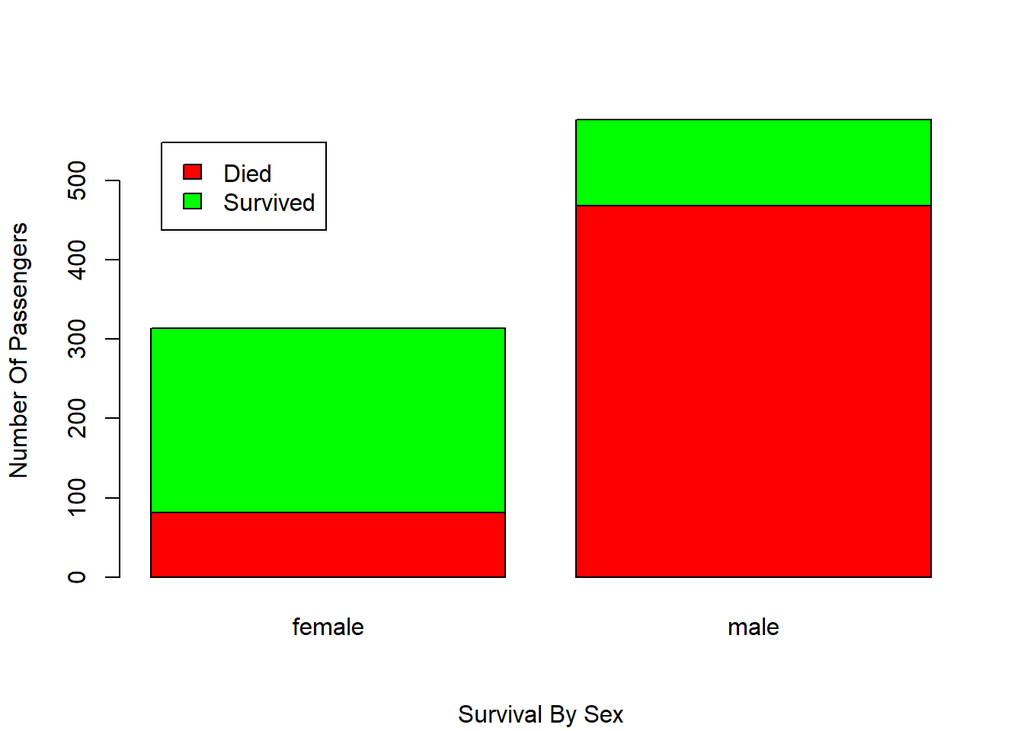

It’s Obvious That The Female Survived More Than Men Which Gives Us an info when We Make the Predictive Model Let’s Make Another Assumption That The Women And Children Survived More Than Men So Let’s Check it Out

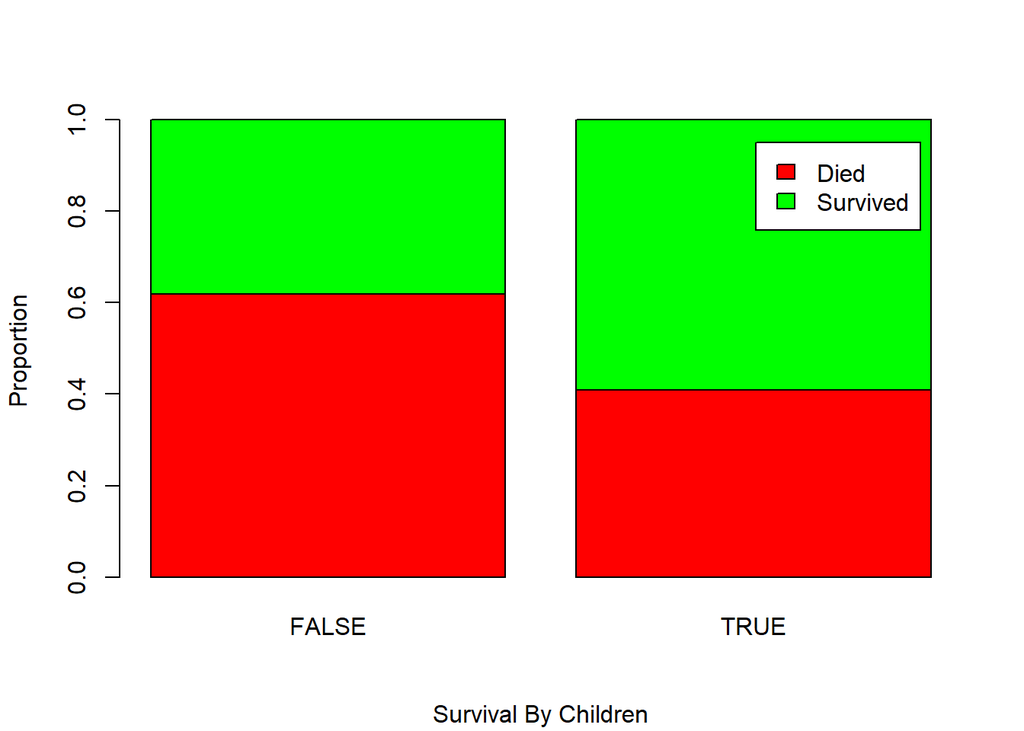

```r
temp.data<-train[!is.na(train$Age),]
temp.data$Child<-temp.data$Age<16
barplot(prop.table(table(temp.data$Survived,temp.data$Child),2),
        sub = "Survival By Children",
        ylab = "Proportion",
        col = c("Red","Green"))
legend("topright",legend=c("Died","Survived"),fil=c("Red","Green"),inset=0.05)
```

So Our Assumption Is True So Let’s Leave that For Now and Clean Our Data.

## $Removing NAs$

Let’s Look Again At Our Variables.

```
##   PassengerId      Survived          Pclass          Name
##  Min.   :   1   Min.   :0.0000   Min.   :1.000   Length:1309
##  1st Qu.: 328   1st Qu.:0.0000   1st Qu.:2.000   Class :character
##  Median : 655   Median :0.0000   Median :3.000   Mode  :character
##  Mean   : 655   Mean   :0.3838   Mean   :2.295
##  3rd Qu.: 982   3rd Qu.:1.0000   3rd Qu.:3.000
##  Max.   :1309   Max.   :1.0000   Max.   :3.000
##                 NA's   :418
##      Sex                 Age            SibSp            Parch
##  Length:1309        Min.   : 0.17   Min.   :0.0000   Min.   :0.000
##  Class :character   1st Qu.:21.00   1st Qu.:0.0000   1st Qu.:0.000
##  Mode  :character   Median :28.00   Median :0.0000   Median :0.000
##                     Mean   :29.88   Mean   :0.4989   Mean   :0.385
##                     3rd Qu.:39.00   3rd Qu.:1.0000   3rd Qu.:0.000
##                     Max.   :80.00   Max.   :8.0000   Max.   :9.000
##                     NA's   :263
##     Ticket               Fare            Cabin
##  Length:1309        Min.   :  0.000   Length:1309
##  Class :character   1st Qu.:  7.896   Class :character
##  Mode  :character   Median : 14.454   Mode  :character
##                     Mean   : 33.295
##                     3rd Qu.: 31.275
##                     Max.   :512.329
##                     NA's   :1
##    Embarked          IsTrain
##  Length:1309        Mode :logical
##  Class :character   FALSE:418
##  Mode  :character   TRUE :891
##                     NA's :0
##
##
##
```

As We See The Variables(Fare,Age) Have NAs in Them So Let’s Start With Age. I’ll do something very basic but it isn’t that accurate, I’ll Fill The NAs With The Median Of The Age and do the same thing with the Fare So Let’s Do This

```r
agemedian<-median(full$Age,na.rm = TRUE)
faremedian<-median(full$Fare,na.rm = TRUE)
full[is.na(full$Age),"Age"]<-agemedian
full[is.na(full$Fare),"Fare"]<-faremedian
```

And From Seeing Other EDAs I saw that the emarked has a missing value too

```r
table(full$Embarked)
```

```
##
##       C   Q   S
##   2 270 123 914
```

It’s True! There are 2 Values So Let’s Correct Them.

```r
full[full$Embarked=='',"Embarked"]<- 'S'
```

Let’s Look After The Cleaning.

```
##   PassengerId      Survived          Pclass          Name
##  Min.   :   1   Min.   :0.0000   Min.   :1.000   Length:1309
##  1st Qu.: 328   1st Qu.:0.0000   1st Qu.:2.000   Class :character
##  Median : 655   Median :0.0000   Median :3.000   Mode  :character
##  Mean   : 655   Mean   :0.3838   Mean   :2.295
##  3rd Qu.: 982   3rd Qu.:1.0000   3rd Qu.:3.000
##  Max.   :1309   Max.   :1.0000   Max.   :3.000
##                 NA's   :418
##      Sex                 Age            SibSp            Parch
##  Length:1309        Min.   : 0.17   Min.   :0.0000   Min.   :0.000
##  Class :character   1st Qu.:22.00   1st Qu.:0.0000   1st Qu.:0.000
##  Mode  :character   Median :28.00   Median :0.0000   Median :0.000
##                     Mean   :29.50   Mean   :0.4989   Mean   :0.385
##                     3rd Qu.:35.00   3rd Qu.:1.0000   3rd Qu.:0.000
##                     Max.   :80.00   Max.   :8.0000   Max.   :9.000
##
##     Ticket               Fare            Cabin
##  Length:1309        Min.   :  0.000   Length:1309
##  Class :character   1st Qu.:  7.896   Class :character
##  Mode  :character   Median : 14.454   Mode  :character
##                     Mean   : 33.281
##                     3rd Qu.: 31.275
##                     Max.   :512.329
##
##    Embarked          IsTrain
##  Length:1309        Mode :logical
##  Class :character   FALSE:418
##  Mode  :character   TRUE :891
##                     NA's :0
##
##
##
```

Sounds Good To Continue To Our Next Step.

## $New Features$

### Nobles ?

A Good Feature We Can Add that we Can See The relation between the Survival and the nobles that they were on the ship so let’s Seperate Them And Combine the rare titles as well.

```r
full$Title <- sapply(full$Name, FUN=function(x) {strsplit(x, split='[,.]')[[1]][2]})
full$Title <- sub(' ', '', full$Title)
full$Title[full$Title %in% c('Mme', 'Mlle')] <- 'Mlle'
full$Title[full$Title %in% c('Capt', 'Don', 'Major', 'Sir')] <- 'Sir'
full$Title[full$Title %in% c('Dona', 'Lady', 'the Countess', 'Jonkheer')] <- 'Lady'
table(full$Title)
```

```
##
##    Col     Dr   Lady Master   Miss   Mlle     Mr    Mrs     Ms    Rev
##      4      8      4     61    260      3    757    197      2      8
##    Sir
##      5
```

### Travelling Alone

Many EDAs have pointed out that the variables Parch and Sibsp contain hidden information about a passenger’s family. SibSp tells us how many siblings or spouses are travelling onboard and Parch tells us how many parents or children are onboard. We can use this information to tell how many people the passenger was travelling with, which might have an impact on whether they survived or not.

```r
full$Fsize <- full$SibSp + full$Parch + 1
```

After That We Convert The Variables We Need to Factors To Complete Prediction

```r
full$Survived<-as.factor(full$Survived)
full$Sex<-as.factor(full$Sex)
full$Pclass<-as.factor(full$Pclass)
full$Embarked<-as.factor(full$Embarked)
full$Title<-as.factor(full$Title)
```

## Make Prediction Using Decision Tree

Let’s Seperate the 2 DS So We can Do Our Prediction

```r
train<-full[full$IsTrain==TRUE,]
test<-full[full$IsTrain==FALSE,]
```

I’m Gonna Use Decision Trees Because That’s What I Slightly Understood

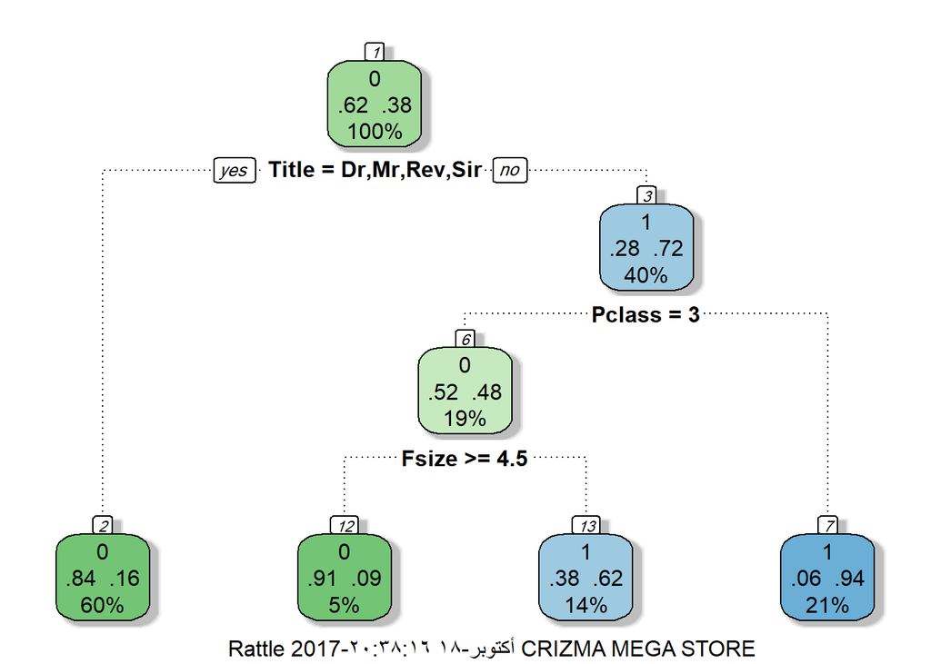

```r
modelfit<-rpart(Survived ~ Pclass + Sex + Age + SibSp + Parch + Fare + Embarked + Title + Fsize,data=train,
               method="class")
fancyRpartPlot(modelfit)
```

So Let’s Apply To Test

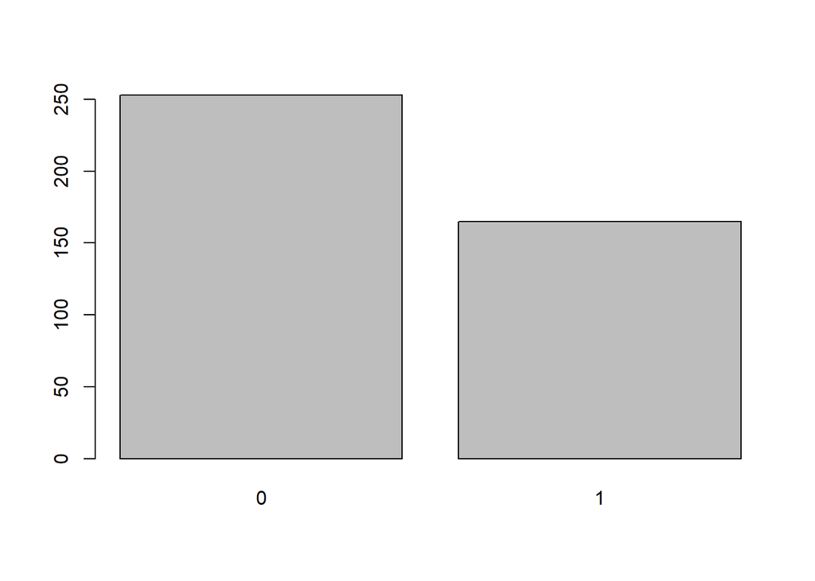

```r
Survived<- predict(modelfit,test,type="class")
test$Survived<-Survived

plot(test$Survived)
```